# STAT6011 Assignment 3

Lee Lap San 3036373312

2025-11-30

# 1a

## Lemma

We will make use of the following lemma and corollary often in this section:

**Lemma 1** *For every random variable $X$ with $\mathbb{E}X<\infty$ and finite real number $c$,*
$$\begin{equation}
\mathbb{E}(X-c)^2=(\mathbb{E}X-c)^2+Var(X)
\end{equation}$$

Proof: $E(X-c)^2=E[(X-EX)+(EX-c)]^2=E(X-EX)^2+2E(X-EX)(EX-c)+(EX-c)^2=(EX-c)^2+Var(X)$

**Corollary 1** *For finite real numbers $u, \{c_i, d_i\}_{i=1}^n$, suppose $d_i > 0$ for every $i$, then*
$$\begin{align}
\sum_{i=1}^n d_i(u-c_i)^2 &= (\sum_{i=1}^n
d_i)(u-\sum_{i=1}^n\frac{d_i}{\sum_{i=1}^n d_i}c_i)^2 + \sum_{i=1}^n
d_i(c_i - \sum_{i=1}^n \frac{d_i}{\sum_{i=1}^n d_i}c_i)^2 \\
&= (\sum_{i=1}^n d_i)(u-\sum_{i=1}^n\frac{d_i}{\sum_{i=1}^n
d_i}c_i)^2 + \sum_{i=1}^n d_i c_i^2 - \frac{(\sum_{i=1}^n d_i
c_i)^2}{(\sum_{i=1}^n d_i)}
\end{align}$$

Proof: Consider a discrete random variable $T$ with
$$\begin{align}
P(T=t)=
\begin{cases}
\frac{d_i}{\sum_{i=1}^n d_i} &\quad\text{, if } t=c_i \\
0 &\quad\text{, otherwise}
\end{cases}
\end{align}$$
and then apply lemma 1.

## Model Specification

We consider the random-effects model:

$$y_{ij} = \beta_0 + \beta_1 x_{ij} + u_i + \varepsilon_{ij}, \quad
\varepsilon_{ij} \sim N(0, \sigma_\varepsilon^2), \quad
u_i \sim N(0, \sigma_u^2)$$

for $i = 1,\dots,n$ and $j = 1,\dots,J$.

The unknown parameter vector is:

$$\theta = (\beta_0, \beta_1, \sigma_u^2, \sigma_\varepsilon^2)^\top$$

## Complete-Data Log-Likelihood

The joint density:

$$L_c(\mathbf(\theta)) = \prod_{i=1}^n (f(y_{ij}, u_i \mid \theta)) =
\prod_{i=1}^n (f(u_i) \prod_{j=1}^J f(y_{ij} \mid u_i))$$

where:

$$u_i \sim N(0, \sigma_u^2), \quad
y_{ij} \mid u_i \sim N(\beta_0 + \beta_1 x_{ij} + u_i,
\sigma_\varepsilon^2)$$

Thus, the complete log-likelihood is:

$$\ell_c(\theta) =
\sum_{i=1}^n \Bigg[
-\frac{J}{2}\log(2\pi\sigma_\varepsilon^2)
-\frac{1}{2\sigma_\varepsilon^2}\sum_{j=1}^J (y_{ij} - \beta_0 - \beta_1
x_{ij} - u_i)^2
-\frac{1}{2}\log(2\pi\sigma_u^2)
-\frac{u_i^2}{2\sigma_u^2}
\Bigg]$$

Expanding constants:

$$\begin{align}
\ell_c(\theta) &=
-\frac{nJ}{2}\log(2\pi)
-\frac{nJ}{2}\log\sigma_\varepsilon^2
-\frac{1}{2\sigma_\varepsilon^2}\sum_{i,j}(y_{ij} - \beta_0 - \beta_1
x_{ij} - u_i)^2
-\frac{n}{2}\log(2\pi)
-\frac{n}{2}\log\sigma_u^2
-\frac{1}{2\sigma_u^2}\sum_i u_i^2 \\
&= -\frac{n(J+1)}{2}\log(2\pi)
-\frac{nJ}{2}\log\sigma_\varepsilon^2
-\frac{1}{2\sigma_\varepsilon^2}\sum_{i,j}(y_{ij} - \beta_0 - \beta_1
x_{ij} - u_i)^2
-\frac{n}{2}\log\sigma_u^2
-\frac{1}{2\sigma_u^2}\sum_i u_i^2
\end{align}$$

## E-Step: Q-Function

The Q-function is:

$$Q(\theta \mid y, \theta^{(t)}) = \mathbb{E}_{u \mid y,
\theta^{(t)}}[\ell_c(\theta)]$$

### Conditional distribution

Noting that $u_i$ depends only on $\{y_{ij}\}_j$, conditional distribution $h(u_i \mid \{y_{ij}\}_{ij},\mathbf{\theta})$ is given by:
$$\begin{align}
h(u_i \mid \{y_{ij}\}_{ij},\mathbf{\theta}) &= h(u_i \mid
\{y_{ij}\}_j,\mathbf{\theta}) \\
&\propto f(y_{ij}, u_i \mid \theta) \\
&= \exp(l_c(\theta)) \\
&\propto
\exp(-\frac{1}{2}[\frac{1}{\sigma_\varepsilon^2}\sum_{i,j}(y_{ij} -
\beta_0 - \beta_1 x_{ij} - u_i)^2+\frac{1}{\sigma_u^2}\sum_i u_i^2]) \\
&\propto
\exp(-\frac{1}{2}[\frac{1}{\sigma_\varepsilon^2}\sum_{j}(y_{ij} -
\beta_0 - \beta_1 x_{ij} - u_i)^2+\frac{1}{\sigma_u^2} u_i^2]) \\
&\propto \exp(-\frac{1}{2}[\frac{1}{C}(u_i-m_i)^2])
\end{align}$$
where by corollary 1,
$$\begin{equation}
m_i=\frac{\frac{1}{\sigma_\varepsilon^2}\sum_j (y_{ij} - \beta_0 -
\beta_1 x_{ij})}{\frac{J}{\sigma_\varepsilon^2}+\frac{1}{\sigma_u^2}} =
\frac{\sigma_u^2}{J\sigma_u^2 + \sigma_\varepsilon^2} \sum_{j=1}^J
(y_{ij} - \beta_0 - \beta_1 x_{ij}), \\
C=(\frac{J}{\sigma_\varepsilon^2}+\frac{1}{\sigma_u^2})^{-1}=\frac{\sigma_u^2
\sigma_\varepsilon^2}{J\sigma_u^2 + \sigma_\varepsilon^2}
\end{equation}$$

Thus, $u_i \mid \theta, y \sim N(m_i, C)$

Note also that $\{u_i\}_i$ are independent, plugging in:

$$Q(\theta) =
-\frac{nJ}{2}\log(2\pi)
-\frac{nJ}{2}\log\sigma_\varepsilon^2
-\frac{1}{2\sigma_\varepsilon^2}\sum_{i,j}\mathbb{E}_{u \mid y,
\theta^{(t)}}[(y_{ij} - \beta_0 - \beta_1 x_{ij} - u_i)^2]
-\frac{n}{2}\log(2\pi)
-\frac{n}{2}\log\sigma_u^2
-\frac{1}{2\sigma_u^2}\sum_i \mathbb{E}_{u \mid y, \theta^{(t)}}[u_i^2]$$

Expand the expectation, employing lemma 1:

$$\mathbb{E}_{u \mid y, \theta^{(t)}}[(y_{ij} - \beta_0 - \beta_1 x_{ij} -
u_i)^2] = (y_{ij} - \beta_0 - \beta_1 x_{ij} - \mathbb{E}_{u \mid y,
\theta^{(t)}}u_i)^2 + Var_{u \mid y, \theta^{(t)}}(u_i) = (y_{ij} -
\beta_0 - \beta_1 x_{ij} - m_i^{(t)})^2 + C^{(t)}$$

and

$$\mathbb{E}_{u \mid y, \theta^{(t)}}[u_i^2] = \mathbb{E}^2_{u \mid y,
\theta^{(t)}}u_i + Var_{u \mid y, \theta^{(t)}}(u_i) = (m_i^{(t)})^2 +
C^{(t)}$$

So:

$$\begin{align}
Q(\theta \mid y, \theta^{(t)}) \\
&= -\frac{nJ}{2}\log(2\pi)
-\frac{nJ}{2}\log\sigma_\varepsilon^2
-\frac{1}{2\sigma_\varepsilon^2}\sum_{i,j}[(y_{ij} - \beta_0 - \beta_1
x_{ij} - m_i^{(t)})^2 + C^{(t)}]
-\frac{n}{2}\log(2\pi)
-\frac{n}{2}\log\sigma_u^2
-\frac{1}{2\sigma_u^2}\sum_i((m_i^{(t)})^2 + C^{(t)}) \\
&= -\frac{n(J+1)}{2}\log(2\pi)
-\frac{nJ}{2}\log\sigma_\varepsilon^2
-\frac{1}{2\sigma_\varepsilon^2}\sum_{i,j}[(y_{ij} - \beta_0 - \beta_1
x_{ij} - m_i^{(t)})^2 + C^{(t)}]
-\frac{n}{2}\log\sigma_u^2
-\frac{1}{2\sigma_u^2}\sum_i((m_i^{(t)})^2 + C^{(t)})
\end{align}$$

## M-Step Updates

### Fixed Effects ($\beta_0, \beta_1$)

We minimize:

$$\sum_{i,j}(y_{ij} - \beta_0 - \beta_1 x_{ij} - m_i)^2$$

Define:

$$\tilde{y}_{ij} = y_{ij} - m_i$$

Then the OLS estimates are:

$$\hat{\beta}_1 = \frac{\sum_{i,j}(x_{ij} - \bar{x})(\tilde{y}_{ij} -
\bar{\tilde{y}})}{\sum_{i,j}(x_{ij} - \bar{x})^2}, \quad
\hat{\beta}_0 = \bar{\tilde{y}} - \hat{\beta}_1 \bar{x}$$

where:

$$\bar{x} = \frac{1}{nJ}\sum_{i,j} x_{ij}, \quad
\bar{\tilde{y}} = \frac{1}{nJ}\sum_{i,j} \tilde{y}_{ij}$$

### Variance Component Updates

For $\sigma_\varepsilon^2$:

$$\frac{\partial Q}{\partial \sigma_\varepsilon^2} =
-\frac{nJ}{2\sigma_\varepsilon^2}
+ \frac{1}{2\sigma_\varepsilon^4}\sum_{i,j}[(y_{ij} - \beta_0 - \beta_1
x_{ij} - m_i^{(t)})^2 + C^{(t)}]$$

Setting derivative = 0 gives:

$$\hat{\sigma}_\varepsilon^2 = \frac{1}{nJ}\sum_{i,j}[(y_{ij} - \beta_0 -
\beta_1 x_{ij} - m_i^{(t)})^2 + C^{(t)}] =
\frac{1}{nJ}\sum_{i,j}[(y_{ij} - \beta_0 - \beta_1 x_{ij} -
m_i^{(t)})^2] + C^{(t)}$$

For $\sigma_u^2$:

$$\frac{\partial Q}{\partial \sigma_u^2} =
-\frac{n}{2\sigma_u^2}
+ \frac{1}{2\sigma_u^4}\sum_i((m_i^{(t)})^2 + C^{(t)})$$

Setting derivative = 0 gives:

$$\hat{\sigma}_u^2 = \frac{1}{n}\sum_i((m_i^{(t)})^2 + C^{(t)}) =
\frac{1}{n}\sum_i((m_i^{(t)})^2) + C^{(t)}$$

## EM Algorithm Summary

1. **Initialize** $\theta^{(0)} = (\beta_0^{(0)}, \beta_1^{(0)}, \sigma_u^{2(0)}, \sigma_\varepsilon^{2(0)})$.
2. **E-Step**: Compute $m_i$ and $C$ for all $i$.
3. **M-Step**: Update $\beta_0, \beta_1, \sigma_u^2, \sigma_\varepsilon^2$ using formulas above.
4. Repeat until convergence.

# 1b

Data loading:

```r
# Read the CSV file
data <- read.csv("q1.csv")


# Convert to wide format for convenience: rows = clusters, columns = observations
suppressWarnings(library(tidyr))
x_wide <- pivot_wider(data, id_cols = i, names_from = j, values_from = x)
y_wide <- pivot_wider(data, id_cols = i, names_from = j, values_from = y)

# Extract matrices
x_mat <- as.matrix(x_wide[,-1])  # remove cluster ID column
y_mat <- as.matrix(y_wide[,-1])
x <- x_mat
y <- y_mat

# Number of clusters and observations per cluster
n <- nrow(x_mat)
J <- ncol(x_mat)

# Check dimensions
cat("n =", n, "clusters; J =", J, "observations per cluster\n")
```

```
## n = 100 clusters; J = 3 observations per cluster
```

Here we use the observed-data log-likelihood for convergence check. Check 1(c) for derivation.

```r
# Compute observed data log-likelihood
ologlik <- function (par) {

  beta0 <- par[1]; beta1 <- par[2]; sigma_u2 <- par[3]; sigma_e2 <- par[4]

  # Compute a_ij and C
  a <- y - beta0 - beta1 * x
  sum_a2 <- sum(a^2)
  row_sums_a <- rowSums(a)
  sum_row_sqs <- sum(row_sums_a^2)
  sum_x <- sum(x)
  sum_x2 <- sum(x^2)
  C <- (sigma_u2 * sigma_e2) / (J * sigma_u2 + sigma_e2)

  l <- -(n * J / 2) * log(2 * pi) +
    (n /2) * log(C) -
    (n * J / 2) * log(sigma_e2) -
    (n / 2) * log(sigma_u2) -
    (sum_a2 / (2 * sigma_e2)) +
    (C * sum_row_sqs) / (2 * sigma_e2^2)
  l
}
```

We pool all the clusters and use the OLS estimate as initial estimate of $\beta_0, \beta_1, \sigma_\varepsilon^2$. For $\sigma_u^2$, we use sample variance of cluster means as initial estimates.

```r
# Set seed for reproducibility
set.seed(123)

# Initial estimates
lm_fit <- lm(y ~ x, data = data)
beta0_init <- coef(lm_fit)[1]
beta1_init <- coef(lm_fit)[2]
sigma_e2_init <- var(resid(lm_fit))
cluster_means <- aggregate(y ~ i, data = data, mean)$y
sigma_u2_init <- var(cluster_means)

{
cat("Initial beta0:", beta0_init, "\n")
cat("Initial beta1:", beta1_init, "\n")
cat("Initial sigma_e^2:", sigma_e2_init, "\n")
cat("Initial sigma_u^2:", sigma_u2_init, "\n")
}
```

```
## Initial beta0: 1.074631
## Initial beta1: 0.6883151
## Initial sigma_e^2: 2.115629
## Initial sigma_u^2: 1.517793
```

EM algorithm implementation:

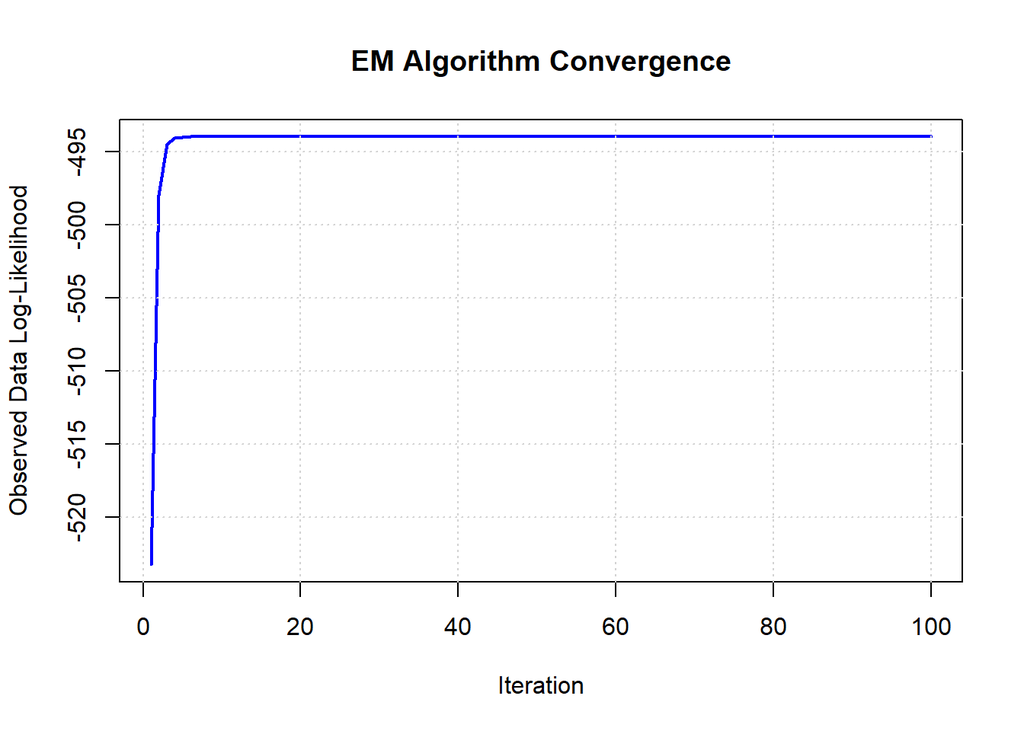

```r
# Global parameters for convergence check
tol <- 1e-6
max_iter <- 100

# Initialize parameters
beta0 <- beta0_init
beta1 <- beta1_init
sigma_u2 <- sigma_u2_init
sigma_e2 <- sigma_e2_init

loglik <- numeric(max_iter)
converged_em <- FALSE
converged_iter_em <- max_iter

# EM Algorithm
for (iter in 1:max_iter) {

  # Compute observed-data log-likelihood for convergence check
  loglik[iter] <- ologlik(c(beta0, beta1, sigma_u2, sigma_e2))

  # Check convergence
  if (!converged_em && iter > 1 && abs(loglik[iter] - loglik[iter - 1]) < tol) {
    converged_em <- TRUE
    converged_iter_em <- iter
    #break
  }

  # E-step: compute C^(t) and m_i^(t)
  C <- (sigma_u2 * sigma_e2) / (J * sigma_u2 + sigma_e2)
  resid_sum <- rowSums(y - beta0 - beta1 * x)
  m <- (sigma_u2 * resid_sum) / (J * sigma_u2 + sigma_e2)

  # M-step: update beta0 and beta1 using OLS on y_ij - m_i
  y_tilde <- as.vector(y - m)
  x_vec <- as.vector(x)
  beta1 <- sum((x_vec - mean(x_vec)) * (y_tilde - mean(y_tilde))) / sum((x_vec - mean(x_vec))^2)
  beta0 <- mean(y_tilde) - beta1 * mean(x_vec)
  # Update variance components
  sigma_u2 <- mean(m^2 + C)
  sigma_e2 <- (sum((y - beta0 - beta1 * x - m)^2) / (n * J)) + C

}

# Plot observed log-likelihood vs iteration
plot(1:max_iter, loglik[1:max_iter], type = "l", col = "blue", lwd = 2,
     xlab = "Iteration", ylab = "Observed Data Log-Likelihood",
     main = "EM Algorithm Convergence")
grid()
```

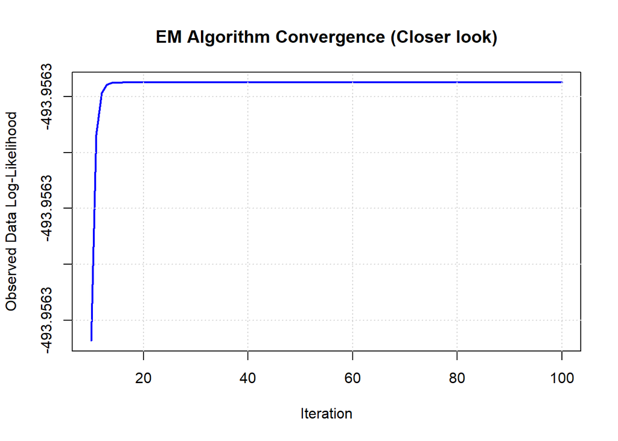

```r
plot((converged_iter_em-2):max_iter, loglik[(converged_iter_em-2):max_iter], type = "l", col = "blue", lwd = 2,
     xlab = "Iteration", ylab = "Observed Data Log-Likelihood",
     main = "EM Algorithm Convergence (Closer look)")
grid()
```

```r
# Print estimates
{
cat("Estimated beta0:", beta0, "\n")
cat("Estimated beta1:", beta1, "\n")
cat("Estimated sigma_u^2:", sigma_u2, "\n")
cat("Estimated sigma_e^2:", sigma_e2, "\n")
if (converged_em) {
  cat("EM algorithm converged at iteration:", converged_iter_em, " at tolerance 1e-6\n")
  cat('EM Estimated Maximum Observed-data Log-likelihood: ', loglik[converged_iter_em])
} else {
  cat("EM algorithm did not converge.")
}
}
```

```
## Estimated beta0: 1.114407
## Estimated beta1: 0.6090106
## Estimated sigma_u^2: 1.17086
## Estimated sigma_e^2: 0.9381997
## EM algorithm converged at iteration: 12  at tolerance 1e-6
## EM Estimated Maximum Observed-data Log-likelihood:  -493.9563
```

# 1c Observed Data Likelihood Derivation

Taking reference to the $\ell_c(\theta)$ derived above, and using corollary 1, we write:
$$\begin{align}
\log f(u_i, \{y_{ij}\}_{j=1}^J \mid \theta) &=
-\frac{J+1}{2}\log(2\pi)
-\frac{J}{2}\log\sigma_\varepsilon^2
-\frac{1}{2}\log\sigma_u^2
- \frac{1}{2}[\frac{1}{C}(u_i-m_i)^2 +
\frac{1}{\sigma_\varepsilon^2}\sum_{j=1}^J a_{ij}^2 -
\frac{C}{\sigma_\varepsilon^4}(\sum_{j=1}^J a_{ij})^2]
\end{align}$$

$$\begin{align}
f(\{y_{ij}\}_{j=1}^J \mid \theta) &= \int_{u_i} f(u_i,
\{y_{ij}\}_{j=1}^J \mid \theta) \\
&= \int_{u_i} \exp(
-\frac{J+1}{2}\log(2\pi)
-\frac{J}{2}\log\sigma_\varepsilon^2
-\frac{1}{2}\log\sigma_u^2
- \frac{1}{2}[\frac{1}{C}(u_i-m_i)^2 +
\frac{1}{\sigma_\varepsilon^2}\sum_{j=1}^J a_{ij}^2 -
\frac{C}{\sigma_\varepsilon^4}(\sum_{j=1}^J a_{ij})^2]) \\
&= \exp(
-\frac{J+1}{2}\log(2\pi)
-\frac{J}{2}\log\sigma_\varepsilon^2
-\frac{1}{2}\log\sigma_u^2
- \frac{1}{2}[\frac{1}{\sigma_\varepsilon^2}\sum_{j=1}^J a_{ij}^2 -
\frac{C}{\sigma_\varepsilon^4}(\sum_{j=1}^J a_{ij})^2]) \cdot
\sqrt{2\pi} \sqrt{C}\\
&= \exp(
-\frac{J}{2}\log(2\pi)
+ \frac{1}{2}\log C
-\frac{J}{2}\log\sigma_\varepsilon^2
-\frac{1}{2}\log\sigma_u^2
- \frac{1}{2\sigma_\varepsilon^2}\sum_{j=1}^J a_{ij}^2
+ \frac{C}{2\sigma_\varepsilon^4}(\sum_{j=1}^J a_{ij})^2),
\end{align}$$
where $a_{ij}= y_{ij} - \beta_0 - \beta_1 x_{ij}$, and $m_i, C$ as defined above.

Observed data likelihood
$$\begin{align}
L(\theta \mid \{y_{ij}\}_{j=1}^J ) \\
&= \prod_{i=1}^n f(\{y_{ij}\}_{j=1}^J \mid \theta) \\
&= \exp(
-\frac{nJ}{2}\log(2\pi)
+ \frac{n}{2}\log C
-\frac{nJ}{2}\log\sigma_\varepsilon^2
-\frac{n}{2}\log\sigma_u^2
- \frac{1}{2\sigma_\varepsilon^2}\sum_{i,j} a_{ij}^2
+ \frac{C}{2\sigma_\varepsilon^4}\sum_{i=1}^n \left(\sum_{j=1}^J
a_{ij}\right)^2) \\
&= (2\pi)^{-\frac{nJ}{2}}
C^{\frac{n}{2}}
\sigma_\varepsilon^{-nJ}
\sigma_u^{-n}
\exp(-\frac{1}{2}[\frac{1}{\sigma_\varepsilon^2} \sum_{i,j} a_{ij}^2 -
\frac{C}{\sigma_\varepsilon^4}\sum_{i=1}^n \left(\sum_{j=1}^J
a_{ij}\right)^2])
\end{align}$$

# 1d MLE via Newton-Raphson

## Observed Log-Likelihood:

Maximizing the observed data likelihood is the same as maximizing the observed data log-likelihood:
$$\begin{align}
l(\theta \mid \{y_{ij}\}_{j=1}^J ) = \log L(\theta \mid
\{y_{ij}\}_{j=1}^J ) =
-\frac{nJ}{2}\log(2\pi)
+ \frac{n}{2}\log C
-\frac{nJ}{2}\log\sigma_\varepsilon^2
-\frac{n}{2}\log\sigma_u^2
- \frac{1}{2\sigma_\varepsilon^2}\sum_{i,j} a_{ij}^2
+ \frac{C}{2\sigma_\varepsilon^4}\sum_{i=1}^n \left(\sum_{j=1}^J
a_{ij}\right)^2
\end{align}$$

## Derivatives of C and Log-Likelihood

We have:
$$C = \frac{\sigma_u^2 \, \sigma_\varepsilon^2}{J \sigma_u^2 +
\sigma_\varepsilon^2}.$$

### Derivatives of C:

$$\frac{\partial C}{\partial \sigma_\varepsilon^2} = \frac{J
(\sigma_u^2)^2}{(J \sigma_u^2 + \sigma_\varepsilon^2)^2}, \quad
\frac{\partial C}{\partial \sigma_u^2} =
\frac{(\sigma_\varepsilon^2)^2}{(J \sigma_u^2 +
\sigma_\varepsilon^2)^2}.$$

### Derivatives:

#### With respect to $\beta_0$:

$$\frac{\partial \ell}{\partial \beta_0} =
\left( \frac{1}{\sigma_\varepsilon^2} - \frac{C J}{\sigma_\varepsilon^4}
\right) \sum_{i,j} a_{ij}.$$

#### With respect to $\beta_1$:

$$\frac{\partial \ell}{\partial \beta_1} =
\frac{1}{\sigma_\varepsilon^2}\sum_{i,j} a_{ij}x_{ij} -
\frac{C}{\sigma_\varepsilon^4} \sum_{i=1}^n \left( \sum_{j=1}^J a_{ij}
\right) \left( \sum_{j=1}^J x_{ij} \right).$$

#### With respect to $\sigma_u^2$:

$$\frac{\partial \ell}{\partial \sigma_u^2} =
\frac{n}{2}\frac{1}{C}\frac{\partial C}{\partial \sigma_u^2} -
\frac{n}{2\sigma_u^2} +
\frac{1}{2\sigma_\varepsilon^4} \sum_{i=1}^n \left( \sum_{j=1}^J a_{ij}
\right)^2 \frac{\partial C}{\partial \sigma_u^2},$$
where $\frac{\partial C}{\partial \sigma_u^2} = \frac{(\sigma_\varepsilon^2)^2}{(J\sigma_u^2 + \sigma_\varepsilon^2)^2}$.

So:
$$\frac{\partial \ell}{\partial \sigma_u^2} =
\frac{n(\sigma_\varepsilon^2)^2}{2C(J\sigma_u^2 +
\sigma_\varepsilon^2)^2} -
\frac{n}{2\sigma_u^2} +
\frac{\sum_{i=1}^n \left( \sum_{j=1}^J a_{ij} \right)^2}{2(J\sigma_u^2 +
\sigma_\varepsilon^2)^2}.$$

#### With respect to $\sigma_\varepsilon^2$:

$$\frac{\partial \ell}{\partial \sigma_\varepsilon^2} =
\frac{n}{2}\frac{1}{C}\frac{\partial C}{\partial \sigma_\varepsilon^2} -
\frac{nJ}{2\sigma_\varepsilon^2} +
\frac{\sum a_{ij}^2}{2\sigma_\varepsilon^4} +
\frac{1}{2\sigma_\varepsilon^4} \sum_{i=1}^n \left( \sum_{j=1}^J a_{ij}
\right)^2 \frac{\partial C}{\partial \sigma_\varepsilon^2} -
\frac{C \sum_{i=1}^n \left( \sum_{j=1}^J a_{ij} \right)^2
}{\sigma_\varepsilon^6},$$
where $\frac{\partial C}{\partial \sigma_\varepsilon^2} = \frac{J(\sigma_u^2)^2}{(J\sigma_u^2 + \sigma_\varepsilon^2)^2}$.

So:
$$\frac{\partial \ell}{\partial \sigma_\varepsilon^2} =
\frac{nJ(\sigma_u^2)^2}{2C(J\sigma_u^2 + \sigma_\varepsilon^2)^2} -
\frac{nJ}{2\sigma_\varepsilon^2} +
\frac{\sum a_{ij}^2}{2\sigma_\varepsilon^4} +
\frac{J(\sigma_u^2)^2 \sum_{i=1}^n \left( \sum_{j=1}^J a_{ij} \right)^2
}{2\sigma_\varepsilon^4(J\sigma_u^2 + \sigma_\varepsilon^2)^2} -
\frac{C \sum_{i=1}^n \left( \sum_{j=1}^J a_{ij} \right)^2
}{\sigma_\varepsilon^6}.$$

## Hessian of the Observed Log-Likelihood

### First Derivatives Recap

$$\begin{aligned}
\frac{\partial \ell}{\partial \beta_0} &= \left(
\frac{1}{\sigma_\varepsilon^2} - \frac{C J}{\sigma_\varepsilon^4}
\right) \sum a_{ij}, \\
\frac{\partial \ell}{\partial \beta_1} &=
\frac{1}{\sigma_\varepsilon^2}\sum a_{ij}x_{ij} -
\frac{C}{\sigma_\varepsilon^4} \sum_{i=1}^n \left( \sum_{j=1}^J a_{ij}
\right) \left( \sum_{j=1}^J x_{ij} \right), \\
\frac{\partial \ell}{\partial \sigma_u^2} &=
\frac{n}{2}\frac{1}{C}\frac{\partial C}{\partial \sigma_u^2} -
\frac{n}{2\sigma_u^2} + \frac{1}{2\sigma_\varepsilon^4} \sum_{i=1}^n
\left( \sum_{j=1}^J a_{ij} \right)^2 \frac{\partial C}{\partial
\sigma_u^2}, \\
\frac{\partial \ell}{\partial \sigma_\varepsilon^2} &=
\frac{n}{2}\frac{1}{C}\frac{\partial C}{\partial \sigma_\varepsilon^2} -
\frac{nJ}{2\sigma_\varepsilon^2} + \frac{\sum
a_{ij}^2}{2\sigma_\varepsilon^4} + \frac{1}{2\sigma_\varepsilon^4}
\sum_{i=1}^n \left( \sum_{j=1}^J a_{ij} \right)^2 \frac{\partial
C}{\partial \sigma_\varepsilon^2} - \frac{C \sum_{i=1}^n \left(
\sum_{j=1}^J a_{ij} \right)^2 }{\sigma_\varepsilon^6}.
\end{aligned}$$

### Derivatives of C

$$\frac{\partial C}{\partial \sigma_u^2} =
\frac{(\sigma_\varepsilon^2)^2}{(J\sigma_u^2 + \sigma_\varepsilon^2)^2},
\quad
\frac{\partial C}{\partial \sigma_\varepsilon^2} =
\frac{J(\sigma_u^2)^2}{(J\sigma_u^2 + \sigma_\varepsilon^2)^2}.$$

Second derivatives:
$$\frac{\partial^2 C}{\partial (\sigma_u^2)^2} =
\frac{-2J(\sigma_\varepsilon^2)^2}{(J\sigma_u^2 +
\sigma_\varepsilon^2)^3}, \quad
\frac{\partial^2 C}{\partial (\sigma_\varepsilon^2)^2} =
\frac{-2J^2(\sigma_u^2)^2}{(J\sigma_u^2 + \sigma_\varepsilon^2)^3},
\quad
\frac{\partial^2 C}{\partial \sigma_u^2 \partial \sigma_\varepsilon^2} =
\frac{2J\sigma_u^2\sigma_\varepsilon^2}{(J\sigma_u^2 +
\sigma_\varepsilon^2)^3}.$$

### Full Hessian Matrix $H$ (4×4)

$$H = \begin{pmatrix}
H_{\beta_0,\beta_0} & H_{\beta_0,\beta_1} &
H_{\beta_0,\sigma_u^2} & H_{\beta_0,\sigma_\varepsilon^2} \\
H_{\beta_1,\beta_0} & H_{\beta_1,\beta_1} &
H_{\beta_1,\sigma_u^2} & H_{\beta_1,\sigma_\varepsilon^2} \\
H_{\sigma_u^2,\beta_0} & H_{\sigma_u^2,\beta_1} &
H_{\sigma_u^2,\sigma_u^2} & H_{\sigma_u^2,\sigma_\varepsilon^2} \\
H_{\sigma_\varepsilon^2,\beta_0} & H_{\sigma_\varepsilon^2,\beta_1}
& H_{\sigma_\varepsilon^2,\sigma_u^2} &
H_{\sigma_\varepsilon^2,\sigma_\varepsilon^2}
\end{pmatrix}.$$

### Entries

#### 1. $\beta_0,\beta_0$:

$$H_{\beta_0,\beta_0} = -\frac{nJ}{\sigma_\varepsilon^2} + \frac{C n
J^2}{\sigma_\varepsilon^4}.$$

#### 2. $\beta_1,\beta_1$:

$$H_{\beta_1,\beta_1} = -\frac{\sum x_{ij}^2}{\sigma_\varepsilon^2} +
\frac{C \sum_{i=1}^n \left( \sum_{j=1}^J x_{ij} \right)^2
}{\sigma_\varepsilon^4}.$$

#### 3. $\sigma_u^2,\sigma_u^2$:

$$H_{\sigma_u^2,\sigma_u^2} =
\frac{n}{2(\sigma_u^2)^2} +
\frac{n}{2}\left[-\frac{1}{C^2}\left(\frac{\partial C}{\partial
\sigma_u^2}\right)^2 + \frac{1}{C}\frac{\partial^2 C}{\partial
(\sigma_u^2)^2}\right] +
\frac{1}{2\sigma_\varepsilon^4} \sum_{i=1}^n \left( \sum_{j=1}^J a_{ij}
\right)^2 \frac{\partial^2 C}{\partial (\sigma_u^2)^2}.$$

#### 4. $\sigma_\varepsilon^2,\sigma_\varepsilon^2$:

Start from:
$$\frac{\partial \ell}{\partial \sigma_\varepsilon^2} =
\frac{n}{2}\frac{1}{C}\frac{\partial C}{\partial \sigma_\varepsilon^2}
- \frac{nJ}{2\sigma_\varepsilon^2}
+ \frac{\sum a_{ij}^2}{2\sigma_\varepsilon^4}
+ \frac{1}{2\sigma_\varepsilon^4} \sum_{i=1}^n \left( \sum_{j=1}^J
a_{ij} \right)^2 \frac{\partial C}{\partial \sigma_\varepsilon^2}
- \frac{C \sum_{i=1}^n \left( \sum_{j=1}^J a_{ij} \right)^2
}{\sigma_\varepsilon^6}.$$

Compute second derivative:
$$H_{\sigma_\varepsilon^2,\sigma_\varepsilon^2} =
\frac{n}{2}\left[
-\frac{1}{C^2}\left(\frac{\partial C}{\partial
\sigma_\varepsilon^2}\right)^2
+ \frac{1}{C}\frac{\partial^2 C}{\partial (\sigma_\varepsilon^2)^2}
\right]
+ \frac{nJ}{2\sigma_\varepsilon^4}
- \frac{\sum a_{ij}^2}{\sigma_\varepsilon^6}
+ \frac{\partial}{\partial \sigma_\varepsilon^2}\left(
\frac{1}{2\sigma_\varepsilon^4} \sum_{i=1}^n \left( \sum_{j=1}^J a_{ij}
\right)^2 \frac{\partial C}{\partial \sigma_\varepsilon^2}
\right)
+ \frac{\partial}{\partial \sigma_\varepsilon^2}\left(
-\frac{C \sum_{i=1}^n \left( \sum_{j=1}^J a_{ij} \right)^2
}{\sigma_\varepsilon^6}
\right).$$

Expand the last two terms:

$$\frac{\partial}{\partial \sigma_\varepsilon^2}\left(
\frac{1}{2\sigma_\varepsilon^4} \sum_{i=1}^n \left( \sum_{j=1}^J a_{ij}
\right)^2 \frac{\partial C}{\partial \sigma_\varepsilon^2}
\right)
= \sum_{i=1}^n \left( \sum_{j=1}^J a_{ij} \right)^2 \left[
-\frac{1}{\sigma_\varepsilon^6}\frac{\partial C}{\partial
\sigma_\varepsilon^2}
+ \frac{1}{2\sigma_\varepsilon^4}\frac{\partial^2 C}{\partial
(\sigma_\varepsilon^2)^2}
\right],$$

$$\frac{\partial}{\partial \sigma_\varepsilon^2}\left(
-\frac{C \sum_{i=1}^n \left( \sum_{j=1}^J a_{ij} \right)^2
}{\sigma_\varepsilon^6}
\right)
= \sum_{i=1}^n \left( \sum_{j=1}^J a_{ij} \right)^2 \left[
-\frac{\partial C}{\partial
\sigma_\varepsilon^2}\frac{1}{\sigma_\varepsilon^6}
+ \frac{3C}{\sigma_\varepsilon^8}
\right].$$

Combine everything:

$$\boxed{
H_{\sigma_\varepsilon^2,\sigma_\varepsilon^2} =
\frac{n}{2}\left[
-\frac{1}{C^2}\left(\frac{\partial C}{\partial
\sigma_\varepsilon^2}\right)^2
+ \frac{1}{C}\frac{\partial^2 C}{\partial (\sigma_\varepsilon^2)^2}
\right]
+ \frac{nJ}{2\sigma_\varepsilon^4}
- \frac{\sum a_{ij}^2}{\sigma_\varepsilon^6}
+ \sum_{i=1}^n \left( \sum_{j=1}^J a_{ij} \right)^2 \left[
-\frac{2}{\sigma_\varepsilon^6}\frac{\partial C}{\partial
\sigma_\varepsilon^2}
+ \frac{1}{2\sigma_\varepsilon^4}\frac{\partial^2 C}{\partial
(\sigma_\varepsilon^2)^2}
+ \frac{3C}{\sigma_\varepsilon^8}
\right].
}$$

#### 5. $\beta_0,\beta_1$:

$$H_{\beta_0,\beta_1} = -\frac{\sum x_{ij}}{\sigma_\varepsilon^2} +
\frac{C J (\sum x_{ij})}{\sigma_\varepsilon^4}.$$

#### 6. $\beta_0,\sigma_u^2$:

$$H_{\beta_0,\sigma_u^2} = -\frac{J (\sum
a_{ij})}{\sigma_\varepsilon^4}\frac{\partial C}{\partial \sigma_u^2}$$

#### 7. $\beta_0,\sigma_\varepsilon^2$:

$$H_{\beta_0,\sigma_\varepsilon^2} =
\sum a_{ij} \left[ -\frac{1}{\sigma_\varepsilon^4} - J \left(
\frac{\partial C}{\partial
\sigma_\varepsilon^2}\cdot\frac{1}{\sigma_\varepsilon^4} -
\frac{2C}{\sigma_\varepsilon^6} \right) \right].$$

Split:
$$H_{\beta_0,\sigma_\varepsilon^2} =
-\frac{\sum a_{ij}}{\sigma_\varepsilon^4}
- J (\sum a_{ij})\left[
\frac{\partial C}{\partial
\sigma_\varepsilon^2}\cdot\frac{1}{\sigma_\varepsilon^4}
- \frac{2C}{\sigma_\varepsilon^6}
\right].$$

#### 8. $\beta_1,\sigma_u^2$:

$$H_{\beta_1,\sigma_u^2} = -\frac{ \sum_{i=1}^n \left( \sum_{j=1}^J a_{ij}
\right) \left( \sum_{j=1}^J x_{ij} \right)
}{\sigma_\varepsilon^4}\frac{\partial C}{\partial \sigma_u^2}$$

#### 9. $\beta_1,\sigma_\varepsilon^2$:

$$H_{\beta_1,\sigma_\varepsilon^2} =
-\frac{\sum a_{ij}x_{ij}}{\sigma_\varepsilon^4}
- J (\sum a_{ij}x_{ij})\left[
\frac{\partial C}{\partial
\sigma_\varepsilon^2}\cdot\frac{1}{\sigma_\varepsilon^4}
- \frac{2C}{\sigma_\varepsilon^6}
\right].$$

#### 10. $\sigma_u^2,\sigma_\varepsilon^2$:

$$H_{\sigma_u^2,\sigma_\varepsilon^2} =
\frac{n}{2}\left[-\frac{1}{C^2}\frac{\partial C}{\partial
\sigma_u^2}\frac{\partial C}{\partial \sigma_\varepsilon^2} +
\frac{1}{C}\frac{\partial^2 C}{\partial \sigma_u^2 \partial
\sigma_\varepsilon^2}\right] +
\frac{1}{2\sigma_\varepsilon^4} \sum_{i=1}^n \left( \sum_{j=1}^J a_{ij}
\right)^2 \frac{\partial^2 C}{\partial \sigma_u^2 \partial
\sigma_\varepsilon^2} - \frac{ \sum_{i=1}^n \left( \sum_{j=1}^J a_{ij}
\right)^2 }{\sigma_\varepsilon^6}\frac{\partial C}{\partial \sigma_u^2}.$$

## Newton Raphson iteration

At each iteration, we update to the next parameter estimate by:
$$\begin{equation}
\theta^{(t+1)} = \theta^{(t)} - [\nabla^2 l(\theta^{(t)})]^{-1}\nabla
l(\theta^{(t)})
\end{equation}$$
where $\nabla l$ and $\nabla^2 l$ refers to the gradient and Hessian of the observed log-likelihood respectively.

## Functions for Gradient and Hessian

```r
compute_gradient <- function(params, x, y, n, J) {
  beta0 <- params[1]
  beta1 <- params[2]
  sigma_u2 <- params[3]
  sigma_e2 <- params[4]

  a <- y - beta0 - beta1 * x
  sum_a <- sum(a)
  sum_a2 <- sum(a^2)
  sum_x <- sum(x)
  sum_x2 <- sum(x^2)
  A <- rowSums(a)
  S <- sum(A^2)
  X <- rowSums(x)
  sum_A_X <- sum(A * X)
  sum_ax <- sum(a * x)

  C <- (sigma_u2 * sigma_e2) / (J * sigma_u2 + sigma_e2)
  dC_du <- (sigma_e2^2) / (J * sigma_u2 + sigma_e2)^2
  dC_de <- (J * sigma_u2^2) / (J * sigma_u2 + sigma_e2)^2

  grad <- numeric(4)
  grad[1] <- (sum_a / sigma_e2) - (C * J * sum_a) / sigma_e2^2
  grad[2] <- (sum_ax / sigma_e2) - (C * sum_A_X) / sigma_e2^2
  grad[3] <- (n / (2 * C)) * dC_du - n / (2 * sigma_u2) + (S / (2 * sigma_e2^2)) * dC_du
  grad[4] <- (n / (2 * C)) * dC_de - (n * J) / (2 * sigma_e2) + sum_a2 / (2 * sigma_e2^2) +
             (S / (2 * sigma_e2^2)) * dC_de - (C * S) / sigma_e2^3

  return(grad)
}

compute_hessian <- function(params, x, y, n, J) {
  beta0 <- params[1]
  beta1 <- params[2]
  sigma_u2 <- params[3]
  sigma_e2 <- params[4]

  a <- y - beta0 - beta1 * x
  sum_a <- sum(a)
  sum_a2 <- sum(a^2)
  sum_x <- sum(x)
  sum_x2 <- sum(x^2)
  A <- rowSums(a)
  S <- sum(A^2)
  X <- rowSums(x)
  sum_A_X <- sum(A * X)
  sum_X2 <- sum(X^2)
  sum_ax <- sum(a * x)

  C <- (sigma_u2 * sigma_e2) / (J * sigma_u2 + sigma_e2)
  dC_du <- (sigma_e2^2) / (J * sigma_u2 + sigma_e2)^2
  dC_de <- (J * sigma_u2^2) / (J * sigma_u2 + sigma_e2)^2
  d2C_du2 <- (-2 * J * sigma_e2^2) / (J * sigma_u2 + sigma_e2)^3
  d2C_de2 <- (-2 * J^2 * sigma_u2^2) / (J * sigma_u2 + sigma_e2)^3
  d2C_du_de <- (2 * J * sigma_u2 * sigma_e2) / (J * sigma_u2 + sigma_e2)^3

  H <- matrix(0, 4, 4)

  H[1,1] <- -n * J / sigma_e2 + (C * n * J^2) / sigma_e2^2
  H[2,2] <- -sum_x2 / sigma_e2 + (C * sum_X2) / sigma_e2^2
  H[1,2] <- -sum_x / sigma_e2 + (C * J * sum_x) / sigma_e2^2
  H[2,1] <- H[1,2]

  H[1,4] <- -sum_a / sigma_e2^2 - (J * sum_a) * (dC_de / sigma_e2^2 - 2 * C / sigma_e2^3)
  H[4,1] <- H[1,4]

  H[1,3] <- -(J * sum_a) * (dC_du / sigma_e2^2)
  H[3,1] <- H[1,3]

  H[2,4] <- -sum_ax / sigma_e2^2 - sum_A_X * (dC_de / sigma_e2^2 - 2 * C / sigma_e2^3)
  H[4,2] <- H[2,4]

  H[2,3] <- -sum_A_X * (dC_du / sigma_e2^2)
  H[3,2] <- H[2,3]

  H[3,3] <- n / (2 * sigma_u2^2) +
             (n / 2) * (- (dC_du^2) / C^2 + d2C_du2 / C) +
             (S / (2 * sigma_e2^2)) * d2C_du2

  H[4,4] <- (n / 2) * (- (dC_de^2) / C^2 + d2C_de2 / C) +
              n*J/(2*sigma_e2^2) -
             (sum_a2) / sigma_e2^3 +
             S * (-2 * dC_de / sigma_e2^3 + d2C_de2 / (2 * sigma_e2^2) + 3*C /sigma_e2^4)

  H[3,4] <- (n / 2) * (- (dC_du * dC_de) / C^2 + d2C_du_de / C) +
             (S / (2 * sigma_e2^2)) * d2C_du_de -
            S/sigma_e2^3 * dC_du
  H[4,3] <- H[3,4]

  return(H)
}
```

## Newton-Raphson Implementation

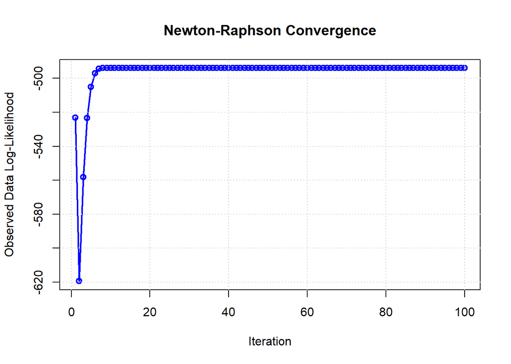

```r
# Reinitialize parameters
beta0 <- beta0_init
beta1 <- beta1_init
sigma_u2 <- sigma_u2_init
sigma_e2 <- sigma_e2_init

params <- c(beta0, beta1, sigma_u2, sigma_e2)
loglik_trace <- numeric(max_iter)
converged_iter_nr <- max_iter
converged_nr <- FALSE

min_var <- 1e-6  # Small positive value to clip variances

clip_count <- 0  # Track how many times clipping occurs

for (iter in 1:max_iter) {

  # Compute observed-data log-likelihood for convergence check
  loglik_trace[iter] <- ologlik(params)

  # Check convergence
  #if (max(abs(delta)) < tol) {
  if (!converged_nr && iter > 1 && abs(loglik_trace[iter] - loglik_trace[iter - 1]) < tol) {
    converged_nr <- TRUE
    converged_iter_nr <- iter
    #break
  }

  # Compute gradient and Hessian using functions
  grad <- compute_gradient(params, x, y, n, J)
  H <- compute_hessian(params, x, y, n, J)

  # Newton-Raphson update
  delta <- solve(H, grad)
  params_new <- params - delta

  # Constrain variances >= min_var
  if (params_new[3] < min_var) {
    params_new[3] <- min_var
    clip_count <- clip_count + 1
  }
  if (params_new[4] < min_var) {
    params_new[4] <- min_var
    clip_count <- clip_count + 1
  }

  # Update parameters
  params <- params_new
  beta0 <- params[1]; beta1 <- params[2]; sigma_u2 <- params[3]; sigma_e2 <- params[4]

}

# Plot log-likelihood trace
plot(1:max_iter, loglik_trace[1:max_iter], type = 'o', col = 'blue', lwd = 2,
     xlab = 'Iteration', ylab = 'Observed Data Log-Likelihood',
     main = 'Newton-Raphson Convergence')
grid()
```

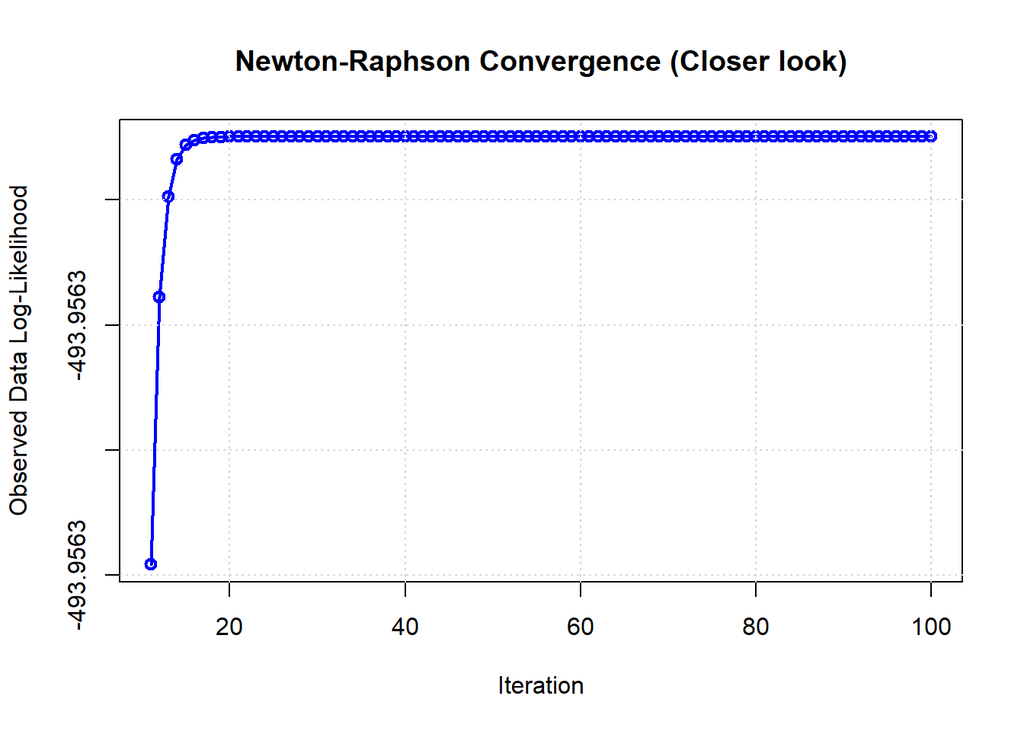

```r
plot((converged_iter_nr-2):max_iter, loglik_trace[(converged_iter_nr-2):max_iter], type = 'o', col = 'blue', lwd = 2,
     xlab = 'Iteration', ylab = 'Observed Data Log-Likelihood',
     main = 'Newton-Raphson Convergence (Closer look)')
grid()
```

```r
names(params) <- c('beta0', 'beta1', 'sigma_u2', 'sigma_e2')
{
cat('NR Estimated beta0:', params[1], '\n')
cat('NR Estimated beta1:', params[2], '\n')
cat('NR Estimated sigma_u^2:', params[3], '\n')
cat('NR Estimated sigma_e^2:', params[4], '\n')
if (converged_nr) {
  cat("Newton-Raphson algorithm converged at iteration:", converged_iter_nr, " at tolerance 1e-6\n")
  cat('NR Estimated Maximum Observed-data Log-likelihood: ', loglik_trace[converged_iter_nr])
} else {
  cat("Newton-Raphson algorithm did not converge.")
}
}
```

```
## NR Estimated beta0: 1.114407
## NR Estimated beta1: 0.6090106
## NR Estimated sigma_u^2: 1.17086
## NR Estimated sigma_e^2: 0.9381997
## Newton-Raphson algorithm converged at iteration: 13  at tolerance 1e-6
## NR Estimated Maximum Observed-data Log-likelihood:  -493.9563
```

As expected, the Newton-Raphson algorithm converges to the same MLE found by the EM algorithm. Their convergence rate are also comparable.

# 1e Gradient Ascent

For each iteration we update by:
$$\begin{equation}
\theta^{(t+1)} = \theta^{(t)} + \eta\nabla l(\theta^{(t)})
\end{equation}$$
where $\eta$ is the learning rate. Since the learning rates 0.1 and 0.5 does not converge to a reasonable MLE, we attempted smaller learning rate 0.01 and 0.001 also

```r
# Gradient Ascent with Log-Likelihood Plot and Variable Learning Rates

# Convergence check parameter for gradient ascent
max_iter_ga <- 1e3
max_iter <- max_iter_ga

# Function to run gradient ascent for a given learning rate
run_gradient_ascent <- function(learning_rate, params_init, max_iter = max_iter_ga, tol = 1e-6) {
  params <- params_init
  beta0 <- params[1]
  beta1 <- params[2]
  sigma_u2 <- params[3]
  sigma_e2 <- params[4]

  loglik_trace <- numeric(max_iter)
  converged_ga <- FALSE
  converged_iter_ga <- max_iter

  for (iter in 1:max_iter) {
    # Compute observed-data log-likelihood for convergence check
    loglik_trace[iter] <- ologlik(params)

    # Check convergence
    if (!converged_ga && iter > 1 && abs(loglik_trace[iter] - loglik_trace[iter - 1]) < tol) {
      converged_ga <- TRUE
      converged_iter_ga <- iter
      #break  # Uncomment to stop early; keep commented to run full iterations for plotting
    }

    # Compute gradient using function
    grad <- compute_gradient(params, x, y, n, J)

    # Gradient ascent update
    params_new <- params + learning_rate * grad

    # Constrain variances >= min_var
    if (params_new[3] < min_var) {
      params_new[3] <- min_var
      clip_count <- clip_count + 1
    }
    if (params_new[4] < min_var) {
      params_new[4] <- min_var
      clip_count <- clip_count + 1
    }

    # Update parameters
    params <- params_new
    beta0 <- params[1]; beta1 <- params[2]; sigma_u2 <- params[3]; sigma_e2 <- params[4]
  }

  list(
    params = params,
    loglik_trace = loglik_trace,
    converged_iter = converged_iter_ga,
    converged = converged_ga
  )
}

# Reinitialize parameters from init
params_init <- c(beta0_init, beta1_init, sigma_u2_init, sigma_e2_init)

# Define a vector of learning rates to try
learning_rates <- c(0.001, 0.01, 0.1, 0.5)

# Run GA for each learning rate and store results
results_list <- list()
for (lr in learning_rates) {
  cat("\nRunning Gradient Ascent with learning rate:", lr, "\n")
  results_list[[as.character(lr)]] <- run_gradient_ascent(lr, params_init)
}
```

```
##
## Running Gradient Ascent with learning rate: 0.001
##
## Running Gradient Ascent with learning rate: 0.01
##
## Running Gradient Ascent with learning rate: 0.1
##
## Running Gradient Ascent with learning rate: 0.5
```

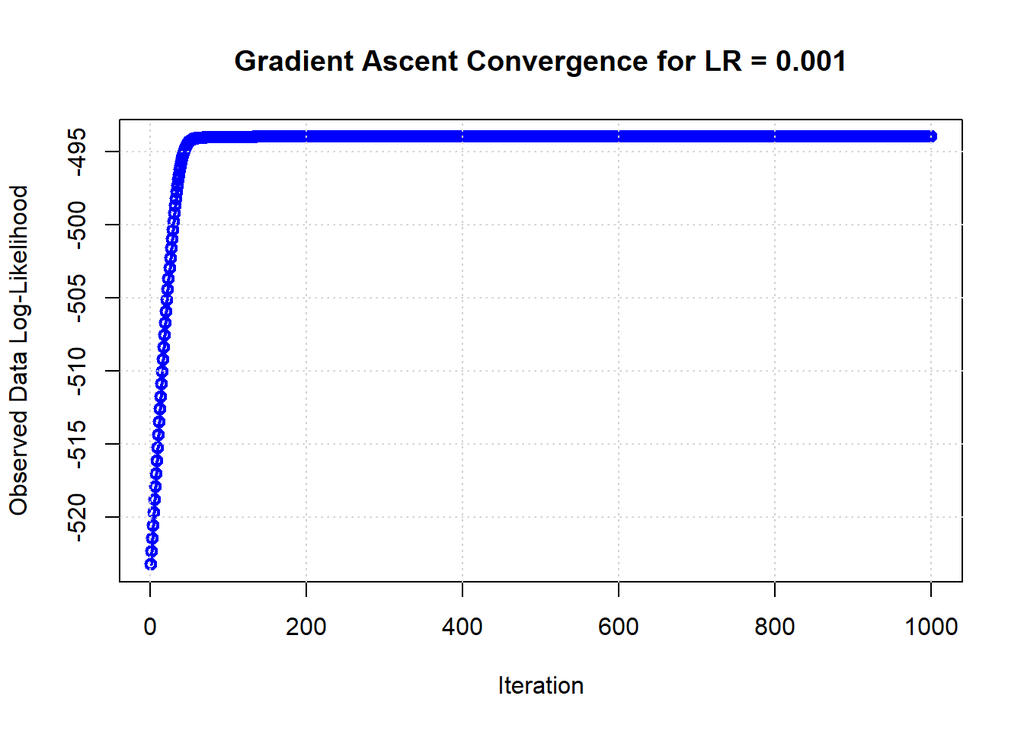

```
## Gradient Ascent with LR= 0.001  converged at iteration: 287  at tolerance 1e-6
```

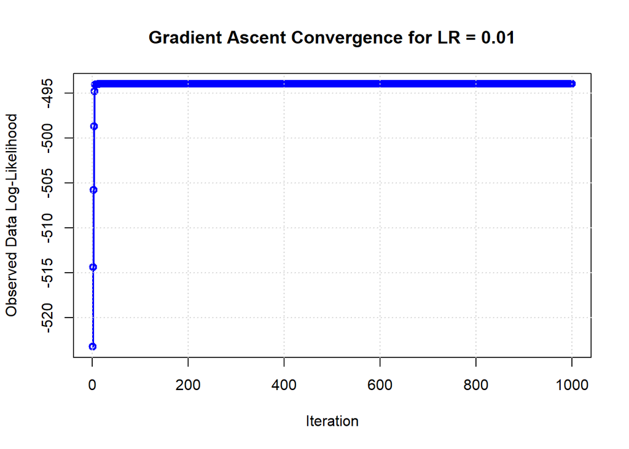

```
## Gradient Ascent with LR= 0.01  converged at iteration: 37  at tolerance 1e-6
```

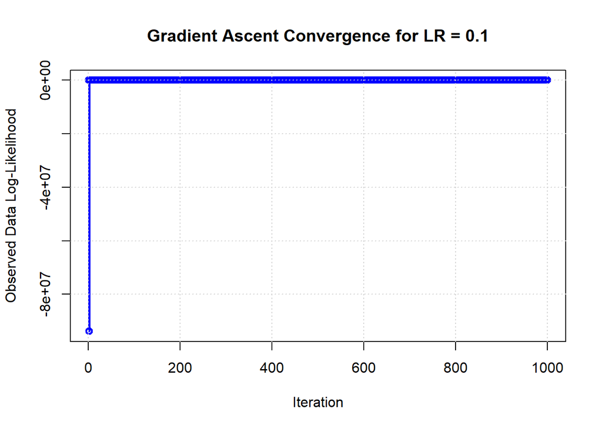

```
## Gradient Ascent with LR= 0.1  converged at iteration: 4  at tolerance 1e-6
```

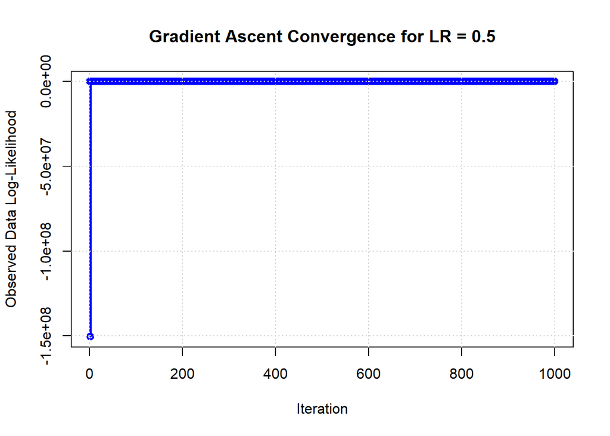

```
## Gradient Ascent with LR= 0.5  converged at iteration: 4  at tolerance 1e-6
```

```r
# Run separate plots for each learning rate
for (i in seq_along(learning_rates)) {
  lr <- learning_rates[i]
  res <- results_list[[as.character(lr)]]
  plot(1:max_iter, res$loglik_trace, type = 'o', col = 'blue', lwd = 2,
       xlab = 'Iteration', ylab = 'Observed Data Log-Likelihood',
       main = paste('Gradient Ascent Convergence for LR =', lr))
  if (res$converged) {
    cat("Gradient Ascent with LR=", lr, " converged at iteration:", res$converged_iter, " at tolerance 1e-6\n")
  } else {
    cat("Gradient Ascent with LR=", lr, " did not converge within", max_iter, "iterations.\n")
  }
  grid()
}
```

```r
# Print final estimates for each LR
for (i in seq_along(learning_rates)) {
  lr <- learning_rates[i]
  res <- results_list[[as.character(lr)]]
  cat("\nFor LR =", lr, ":\n")
  names(res$params) <- c('beta0', 'beta1', 'sigma_u2', 'sigma_e2')
  cat('GA Estimated beta0:', res$params[1], '\n')
  cat('GA Estimated beta1:', res$params[2], '\n')
  cat('GA Estimated sigma_u^2:', res$params[3], '\n')
  cat('GA Estimated sigma_e^2:', res$params[4], '\n')
  cat('GA Estimated Maximum Observed-data Log-likelihood: ', res$loglik_trace[res$converged_iter])
}
```

```
##
## For LR = 0.001 :
## GA Estimated beta0: 1.114407
## GA Estimated beta1: 0.6090107
## GA Estimated sigma_u^2: 1.17086
## GA Estimated sigma_e^2: 0.9381997
## GA Estimated Maximum Observed-data Log-likelihood:  -493.9563
## For LR = 0.01 :
## GA Estimated beta0: 1.114407
## GA Estimated beta1: 0.6090106
## GA Estimated sigma_u^2: 1.17086
## GA Estimated sigma_e^2: 0.9381997
## GA Estimated Maximum Observed-data Log-likelihood:  -493.9563
## For LR = 0.1 :
## GA Estimated beta0: 1.43222
## GA Estimated beta1: -86196.04
## GA Estimated sigma_u^2: 6.82367
## GA Estimated sigma_e^2: 9.383643e+12
## GA Estimated Maximum Observed-data Log-likelihood:  -4756.219
## For LR = 0.5 :
## GA Estimated beta0: 5151284
## GA Estimated beta1: 4301999
## GA Estimated sigma_u^2: 2.118441e+13
## GA Estimated sigma_e^2: 5.406827e+13
## GA Estimated Maximum Observed-data Log-likelihood:  -5129.083
```

As shown in the results, at learning rate 0.1 and 0.5, the gradient ascent algorithm does not converge to a reasonable MLE, convergence is reported likely due to local optimum or numerical instability. For gradient ascent algorithm, only the first moment is used. If the learning rate is too large, the algorithm may jump over the optimal solution easily.

With smaller learning rates 0.01 or 0.001, the gradient ascent algorithm converges to the same MLE found by Newton-Raphson algorithm and EM algorithm. However, the iteration required by the gradient ascent algorithm is 37, larger than that of 13 as required by the Newton-Raphson algorithm. This is expected since the Newton-Raphson algorithm utilizes second-order information. As long as the optimal solution has appropriately large curvature, then the Newton-Raphson algorithm would be appropriate to avoid zig-zag paths of the gradient ascent algorithm.

# 2a

The model is given by
$$\begin{align}
u_i &\sim \text{Cat}(\mathbf{w}) \\
y_i &\mid u_i \sim \mathcal{N}(\mu_{u_i}, \sigma_{u_i}),
\end{align}$$
where $\{u_i\}_i$ are independent and $\{y_i\}_i$ are independent. Let $\theta=(\mathbf{w},\mathbf{\mu},\mathbf{\sigma})$.
$$\begin{align}
f(y_i, u_i \mid \mathbf{\theta}) &= f(y_i \mid u_i,
\mathbf{\theta})f(u_i \mid \mathbf{\theta}) \\
&= (2 \pi)^{-\frac{1}{2}} \sigma_{u_i}^{-1}
\exp({-\frac{(y_i-\mu_{u_i})^2}{2\sigma_{u_i}^2}}) \cdot w_{u_i}
\end{align}$$
Thus, the complete data likelihood, $L^C(\theta \mid \mathbf{y}, \mathbf{u})$ is given by:
$$\begin{align}
L^c(\mathbf{\theta} \mid \mathbf{y}, \mathbf{u}) &= \prod_{i=1}^n
f(y_i, \mu{u_i} \mid \mathbf{\theta}) \\
&= (2\pi)^{-\frac{n}{2}} \prod_{i=1}^n \sigma_{u_i}^{-1}
\exp({-\frac{(y_i-\mu_{u_i})^2}{2\sigma_{u_i}^2}}) \cdot w_{u_i}
\end{align}$$

# 2b

The marginal distribution of $y_i$ is given by:
$$\begin{align}
f(y_i \mid \mathbf{\theta}) &= \sum_{u_i=1}^k f(y_i, u_i \mid
\mathbf{\theta}) \\
&= \sum_{j=1}^k (2\pi)^{-\frac{1}{2}} \sigma_{j}^{-1}
\exp({-\frac{(y_i-\mu_j)^2}{2\sigma_{j}^2}}) \cdot w_{j},
\end{align}$$
consistent with the pdf given in the question.

# 2c

We employ PAM for clustering with different $k$. The best $k$ is estimated through visual inspection of the histogram and by comparing silhoutte width.

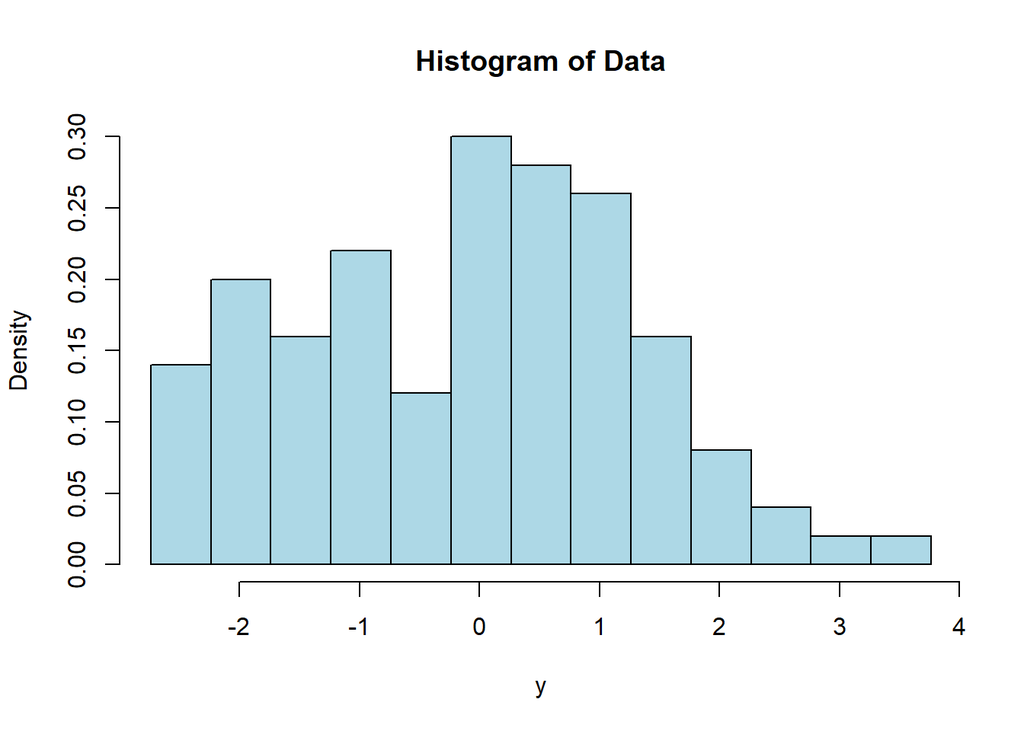

```r
library(cluster)

# Step 1: Read the CSV file
data <- read.csv("q2.csv")
y <- data$y
y_matrix <- as.matrix(y)  # Convert to matrix for clustering functions (1D as single column)

# Step 2: Visualize the raw data with specified binwidth
# Use fixed binwidth
binwidth <- 0.5
# Generate breaks sequence
breaks_seq <- seq(min(y), max(y) + binwidth, by = binwidth)  # Add binwidth to max to include all data
# Plot histogram with specified breaks
hist(y, breaks = breaks_seq, main="Histogram of Data", xlab="y", prob=TRUE, col="lightblue")
```

```r
# Step 3: Determine the optimal number of clusters k using silhouette width
# We'll try k from 2 to 10; skip k=1 as trivial
max_k <- 10
sil_widths <- numeric(max_k - 1)
for (k in 2:max_k) {
  # Use PAM (Partitioning Around Medoids) for clustering
  pam_fit <- pam(y_matrix, k = k)
  sil <- silhouette(pam_fit$clustering, dist(y_matrix))
  sil_widths[k-1] <- summary(sil)$avg.width
}

# Find the k with the maximum average silhouette width
best_k <- which.max(sil_widths) + 1  # +1 since we started from k=2
cat("Estimated number of clusters k (based on max silhouette width):", best_k, "\n")
```

```
## Estimated number of clusters k (based on max silhouette width): 2
```

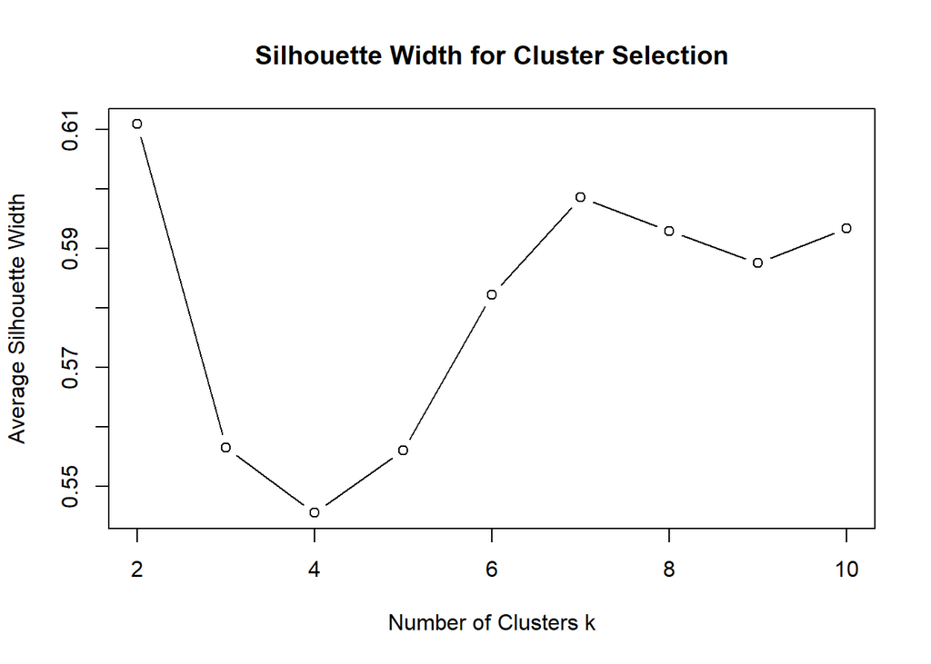

```r
# Plot silhouette widths for model selection
plot(2:max_k, sil_widths, type="b", xlab="Number of Clusters k", ylab="Average Silhouette Width",
     main="Silhouette Width for Cluster Selection")
```

From the histogram, there appears two peaks. The PAM fit shows largest silhoutte width at $k=2$ also. We might estimate $k=2$. We then estimate $\mathbf{\mu}$ and $\mathbf{\sigma^2}$ by sample means and variance of each cluster. Mixing proportion $\mathbf{w}$ is also estimated by the proportion of data points in each cluster.

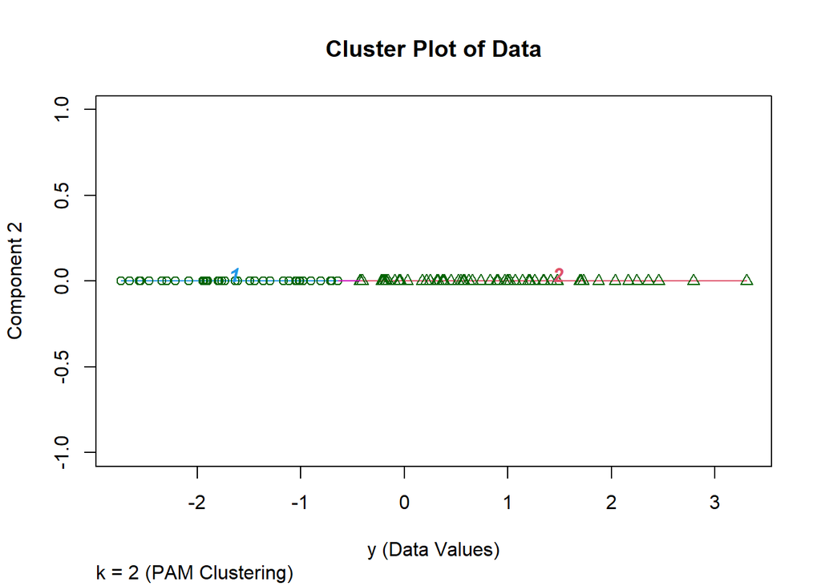

```r
# Step 4: Perform clustering with the best k
pam_best <- pam(y_matrix, k = best_k)

# Step 5: Visualize the clustering using clusplot
# For 1D data, clusplot will plot points on a line with cluster indicators
# Modified to use labels=4 to label clusters (ellipses) but not the individual data points with numbers
clusplot(y_matrix, pam_best$clustering, main="Cluster Plot of Data", shade=TRUE, color=TRUE,
         labels=4, plotchar=TRUE, span=TRUE, xlab="y (Data Values)",
         sub=sprintf("k = %d (PAM Clustering)", best_k))
```

```r
# Step 6: Estimate normal density parameters N(μ_j, σ²_j) for each cluster
# Compute mean and variance for each cluster
clusters <- pam_best$clustering
means <- tapply(y, clusters, mean)
variances <- tapply(y, clusters, var)

{
cat("Estimated parameters:\n")
for (j in 1:best_k) {
  cat(sprintf("Component %d: N(μ=%.4f, σ²=%.4f)\n", j, means[j], variances[j]))
}

# Estimate mixing proportions w_j (proportions of data in each cluster)
proportions <- table(clusters) / length(y)
cat("Estimated mixing proportions w:\n", proportions, "\n")
}
```

```
## Estimated parameters:
## Component 1: N(μ=-1.5964, σ²=0.3663)
## Component 2: N(μ=0.8193, σ²=0.7374)
## Estimated mixing proportions w:
##  0.39 0.61
```

# 2d, e

## E-step

The posterior conditional distribution is given by:
$$\begin{align}
h(u_i \mid y_i, \mathbf{\theta}) &= \frac{f(y_i, u_i \mid
\mathbf{\theta})}{f(y_i \mid \mathbf{\theta})} \\
&= \frac{(2 \pi)^{-\frac{1}{2}} \sigma_{u_i}^{-1}
\exp({-\frac{(y_i-\mu_{u_i})^2}{2\sigma_{u_i}^2}}) \cdot
w_{u_i}}{\sum_{j=1}^k (2\pi)^{-\frac{1}{2}} \sigma_{j}^{-1}
\exp({-\frac{(y_i-\mu_j)^2}{2\sigma_{j}^2}}) \cdot w_{j}} \\
&= \frac{\sigma_{u_i}^{-1}
\exp({-\frac{(y_i-\mu_{u_i})^2}{2\sigma_{u_i}^2}}) \cdot
w_{u_i}}{\sum_{j=1}^k \sigma_{j}^{-1}
\exp({-\frac{(y_i-\mu_j)^2}{2\sigma_{j}^2}}) \cdot w_{j}} \\
&= \frac{\exp({-\frac{(y_i-\mu_{u_i})^2}{2}}) \cdot
w_{u_i}}{\exp({-\frac{(y_i-\mu_1)^2}{2}}) \cdot w_1
+ \exp({-\frac{(y_i-\mu_2)^2}{2}}) \cdot (1- w_1)}, \\
\end{align}$$
noting $k=2$ and $\sigma_1^2=\sigma_2^2=1$. Denote
$$\begin{align}
p_{1,i} &= h(u_i=1\mid y_i, \mathbf{\theta}) = \frac{
\exp({-\frac{(y_i-\mu_1)^2}{2}}) \cdot w_1}{
\exp({-\frac{(y_i-\mu_1)^2}{2}}) \cdot w_1 +
\exp({-\frac{(y_i-\mu_2)^2}{2}}) \cdot (1-w_1)} \\
p_{2,i} &= h(u_i=2\mid y_i, \mathbf{\theta}) = \frac{
\exp({-\frac{(y_i-\mu_2)^2}{2}}) \cdot
w_2}{\exp({-\frac{(y_i-\mu_1)^2}{2}}) \cdot w_1 +
\exp({-\frac{(y_i-\mu_2)^2}{2}}) \cdot w_2} = 1 - p_{1,i}
\end{align}$$
The Q-function is given by:
$$\begin{align}
Q(\mathbf{\theta} \mid \mathbf{y}, \tilde{\mathbf{\theta}}) &=
\mathbb{E}_{\mathbf{u} \mid \mathbf{y}, \tilde{\mathbf{\theta}}}\log
[L^C(\mathbf{\theta} \mid \mathbf{y}, \mathbf{u})] \\
&= \mathbb{E}_{\mathbf{u} \mid \mathbf{y},
\tilde{\mathbf{\theta}}}\log [(2\pi)^{-\frac{n}{2}} \prod_{i=1}^n
\sigma_{u_i}^{-1} \exp({-\frac{(y_i-\mu_{u_i})^2}{2\sigma_{u_i}^2}})
\cdot w_{u_i}] \\
&= -\frac{n}{2}\log(2\pi) + \sum_{i=1}^n \mathbb{E}_{u_i \mid y_i,
\tilde{\mathbf{\theta}}} \log [ \sigma_{u_i}^{-1}
\exp({-\frac{(y_i-\mu_{u_i})^2}{2\sigma_{u_i}^2}}) \cdot w_{u_i}]
\end{align}$$
Now, noting $k=2$ and $\sigma_1^2=\sigma_2^2=1$,
$$\begin{align}
& \mathbb{E}_{u_i \mid y_i, \tilde{\mathbf{\theta}}} \log [
\sigma_{u_i}^{-1} \exp({-\frac{(y_i-\mu_{u_i})^2}{2\sigma_{u_i}^2}})
\cdot w_{u_i}] \\
&= \mathbb{E}_{u_i \mid y_i, \tilde{\mathbf{\theta}}} [\log w_{u_i}
-\frac{(y_i-\mu_{u_i})^2}{2})] \\
&= [\tilde{p}_{1,i} \quad \tilde{p}_{2,i}] [\log w_1
-\frac{(y_i-\mu_1)^2}{2} \quad \log (1-w_1) -\frac{(y_i-\mu_2)^2}{2}]^T,
\end{align}$$
where
$$\begin{align}
\tilde{p}_{1,i} &= h(u_i=1\mid y_i, \tilde{\mathbf{\theta}}) =
\frac{ \exp(-\frac{(y_i-\tilde{\mu}_1)^2}{2}) \cdot \tilde{w}_1}{
\exp(-\frac{(y_i-\tilde{\mu}_1)^2}{2}) \cdot \tilde{w}_1 +
\exp(-\frac{(y_i-\tilde{\mu}_2)^2}{2}) \cdot \tilde{w}_2} \\
\tilde{p}_{2,i} &= h(u_i=2\mid y_i, \tilde{\mathbf{\theta}}) =
\frac{ \exp(-\frac{(y_i-\tilde{\mu}_2)^2}{2}) \cdot \tilde{w}_2}{
\exp(-\frac{(y_i-\tilde{\mu}_1)^2}{2}) \cdot \tilde{w}_1 +
\exp(-\frac{(y_i-\tilde{\mu}_2)^2}{2}) \cdot (1-\tilde{w}_1)} \\
\end{align}$$
Thus,
$$\begin{align}
Q(\mathbf{\mu}, \mathbf{w} \mid \mathbf{y}, \tilde{\mathbf{\mu}},
\tilde{\mathbf{w}}) \\
&= -\frac{n}{2}\log(2\pi) + \sum_{i=1}^n [\tilde{p}_{1,i} \quad
\tilde{p}_{2,i}] [\log w_1 -\frac{(y_i-\mu_1)^2}{2} \quad \log w_2
-\frac{(y_i-\mu_2)^2}{2}]^T \\
&= -\frac{n}{2}\log(2\pi) + (\sum_{i=1}^n \tilde{p}_{1,i})\log w_1 +
(\sum_{i=1}^n \tilde{p}_{2,i})\log (1-w_1) - \frac{1}{2} \sum_{i=1}^n
\tilde{p}_{1,i} (\mu_1 - y_i)^2 - \frac{1}{2} \sum_{i=1}^n
\tilde{p}_{2,i} (\mu_2 - y_i)^2
\end{align}$$

For the case where $w_1=w_2=\frac{1}{2}$ is known, the above simplify as:
$$\begin{align}
Q(\mathbf{\mu} \mid \mathbf{y}, \tilde{\mathbf{\mu}}) \\
&= -\frac{n}{2}\log(2\pi) + (\sum_{i=1}^n \tilde{p}_{1,i})\log w_1 +
(\sum_{i=1}^n \tilde{p}_{2,i})\log (1-w_1) - \frac{1}{2} \sum_{i=1}^n
\tilde{p}_{1,i} (\mu_1 - y_i)^2 - \frac{1}{2} \sum_{i=1}^n
\tilde{p}_{2,i} (\mu_2 - y_i)^2 \\
&= -\frac{n}{2}\log(2\pi) + (\sum_{i=1}^n \tilde{p}_{1,i})\log
\frac{1}{2} + (\sum_{i=1}^n \tilde{p}_{2,i})\log \frac{1}{2} -
\frac{1}{2} \sum_{i=1}^n \tilde{p}_{1,i} (\mu_1 - y_i)^2 - \frac{1}{2}
\sum_{i=1}^n \tilde{p}_{2,i} (\mu_2 - y_i)^2 \\
&= -\frac{n}{2}\log(2\pi) + (\sum_{i=1}^n (\tilde{p}_{1,i} +
\tilde{p}_{2,i})\log \frac{1}{2}) - \frac{1}{2} \sum_{i=1}^n
\tilde{p}_{1,i} (\mu_1 - y_i)^2 - \frac{1}{2} \sum_{i=1}^n
\tilde{p}_{2,i} (\mu_2 - y_i)^2 \\
&= -\frac{n}{2}\log(2\pi) + (\sum_{i=1}^n \log \frac{1}{2}) -
\frac{1}{2} \sum_{i=1}^n \tilde{p}_{1,i} (\mu_1 - y_i)^2 - \frac{1}{2}
\sum_{i=1}^n \tilde{p}_{2,i} (\mu_2 - y_i)^2 \\
&= -\frac{n}{2}\log(2\pi) - n\log 2 - \frac{1}{2} \sum_{i=1}^n
\tilde{p}_{1,i} (\mu_1 - y_i)^2 - \frac{1}{2} \sum_{i=1}^n
\tilde{p}_{2,i} (\mu_2 - y_i)^2
\end{align}$$
with
$$\begin{align}
\tilde{p}_{1,i} &= h(u_i=1\mid y_i, \tilde{\mathbf{\theta}}) =
\frac{ \exp(-\frac{(y_i-\tilde{\mu}_1)^2}{2})}{
\exp(-\frac{(y_i-\tilde{\mu}_1)^2}{2}) +
\exp(-\frac{(y_i-\tilde{\mu}_2)^2}{2})} \\
\tilde{p}_{2,i} &= h(u_i=2\mid y_i, \tilde{\mathbf{\theta}}) =
\frac{ \exp(-\frac{(y_i-\tilde{\mu}_2)^2}{2})}{
\exp(-\frac{(y_i-\tilde{\mu}_1)^2}{2}) +
\exp(-\frac{(y_i-\tilde{\mu}_2)^2}{2})} \\
\end{align}$$

## M-step

Consider the simplified case (d) first. To maximize $Q(\mathbf{\theta} \mid \mathbf{y}, \tilde{\mathbf{\theta}})$, take derivative and set to zero:
$$\begin{align}
\frac{\partial Q(\mathbf{\theta} \mid \mathbf{y},
\tilde{\mathbf{\theta}})}{\partial \mu_1} &= -\sum_{i=1}^n
\tilde{p}_{1,i} (\mu_1 - y_i) = 0 \\
\mu_1 &= \frac{\sum_{i=1}^n \tilde{p}_{1,i} y_i}{\sum_{i=1}^n
\tilde{p}_{1,i}}
\end{align}$$
Similarly,
$$\begin{align}
\mu_2 = \frac{\sum_{i=1}^n \tilde{p}_{2,i} y_i}{\sum_{i=1}^n
\tilde{p}_{2,i}}
\end{align}$$

Then consider the complicated case (e). For $\mathbf{\mu}$, aking derivatives and setting to zero yields the same equations as above, just that the corresponding E-step equations for $\tilde{\mathbf{p}}$ has to be used, which involve terms of $\tilde{w}$. For $\mathbf{w}$,
$$\begin{align}
\frac{\partial Q(\mathbf{\theta} \mid \mathbf{y},
\tilde{\mathbf{\theta}})}{\partial w_1} =
\frac{(\sum_{i=1}^n \tilde{p}_{1,i})}{w_1} - \frac{(\sum_{i=1}^n
\tilde{p}_{2,i})}{(1-w_1)} = 0 \\
w_1 = \frac{\sum_{i=1}^n \tilde{p}_{1,i}}{\sum_{i=1}^n
(\tilde{p}_{1,i}+\tilde{p}_{2,i})} = \frac{1}{n}\sum_{i=1}^n
\tilde{p}_{1,i}
\end{align}$$
and
$$\begin{align}
w_2 = 1 - w_1 = \frac{1}{n}\sum_{i=1}^n \tilde{p}_{2,i}
\end{align}$$

```r
n <- length(y)

# Initialize parameters
# Use k-means for initial guesses of mu1 and mu2
init_kmeans <- kmeans(y, centers = 2)
mu1 <- init_kmeans$centers[1]
mu2 <- init_kmeans$centers[2]
# Fixed parameters
sigma1 <- 1
sigma2 <- 1
w1 <- 0.5
w2 <- 0.5

# Convergence criteria
tol <- 1e-6
max_iter <- 100
iter <- 0
converged <- FALSE

# EM algorithm loop
while (!converged && iter < max_iter) {
  iter <- iter + 1

  # E-step: Compute responsibilities \tilde{p}_{1,i} and \tilde{p}_{2,i}
  # Note: Since w1 = w2 and sigma1 = sigma2, they cancel out in the ratio
  exp_term1 <- exp(- (y - mu1)^2 / 2)
  exp_term2 <- exp(- (y - mu2)^2 / 2)
  p1 <- exp_term1 / (exp_term1 + exp_term2)
  p2 <- 1 - p1  # or exp_term2 / (exp_term1 + exp_term2)

  # M-step: Update mu1 and mu2
  sum_p1 <- sum(p1)
  sum_p2 <- sum(p2)
  new_mu1 <- sum(p1 * y) / sum_p1
  new_mu2 <- sum(p2 * y) / sum_p2
  # No updates for w or sigma since fixed

  # Check convergence
  delta <- max(abs(new_mu1 - mu1), abs(new_mu2 - mu2))
  if (delta < tol) {
    converged <- TRUE
  }

  # Update parameters
  mu1 <- new_mu1
  mu2 <- new_mu2
}

# Output results
{
if (converged) {
  cat("EM converged after", iter, "iterations.\n")
} else {
  cat("EM reached maximum iterations (", max_iter, ") without convergence.\n")
}
cat("Estimated mu_1:", mu1, "\n")
cat("Estimated mu_1:", mu2, "\n")
}
```

```
## EM converged after 16 iterations.
## Estimated mu_1: 0.8744075
## Estimated mu_1: -1.16448
```

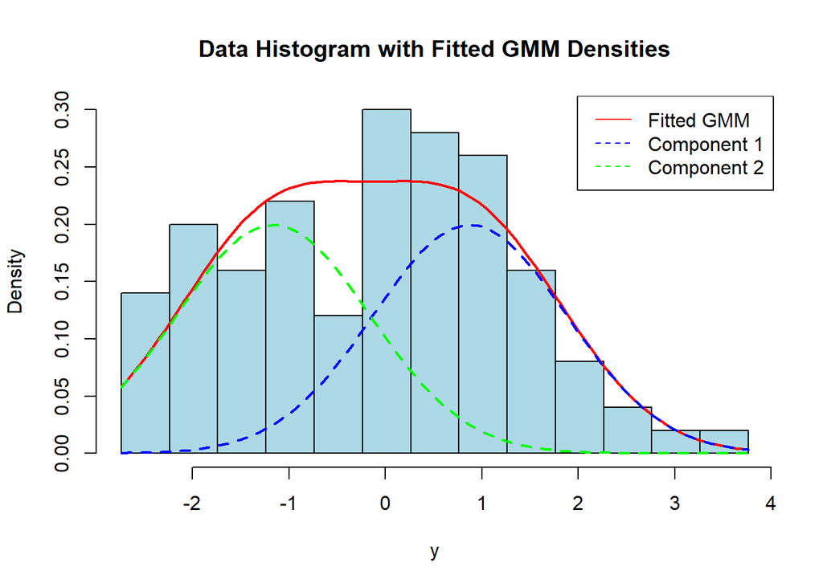

```r
# Visualize the fitted densities over histogram
hist(y, prob = TRUE, breaks = breaks_seq, col = "lightblue", main = "Data Histogram with Fitted GMM Densities", xlab = "y")
curve(w1 * dnorm(x, mean = mu1, sd = sigma1) + w2 * dnorm(x, mean = mu2, sd = sigma2), add = TRUE, col = "red", lwd = 2)
curve(w1 * dnorm(x, mean = mu1, sd = sigma1), add = TRUE, col = "blue", lty = 2, lwd=2)
curve(w2 * dnorm(x, mean = mu2, sd = sigma2), add = TRUE, col = "green", lty = 2, lwd=2)
legend("topright", legend = c("Fitted GMM", "Component 1", "Component 2"), col = c("red", "blue", "green"), lty = c(1, 2, 2))
```

```r
# Initialize parameters
# Using previous means for initial guesses of mu1 and mu2
# Initialize weights
w1 <- 0.5
w2 <- 0.5
# Fixed parameters
sigma1 <- 1
sigma2 <- 1

# Convergence criteria
tol <- 1e-6
max_iter <- 100
iter <- 0
converged <- FALSE

# EM algorithm loop
while (!converged && iter < max_iter) {
  iter <- iter + 1

  # E-step: Compute responsibilities \tilde{p}_{1,i} and \tilde{p}_{2,i}
  exp_term1 <- exp(- (y - mu1)^2 / 2)
  exp_term2 <- exp(- (y - mu2)^2 / 2)
  denom <- exp_term1 * w1 + exp_term2 * w2
  p1 <- (exp_term1 * w1) / denom
  p2 <- 1 - p1 # or (exp_term2 * w2) / denom

  # M-step: Update mu1, mu2, w1, w2
  sum_p1 <- sum(p1)
  sum_p2 <- sum(p2)
  new_mu1 <- sum(p1 * y) / sum_p1
  new_mu2 <- sum(p2 * y) / sum_p2
  new_w1 <- sum_p1 / n
  new_w2 <- sum_p2 / n  # Alternatively, 1 - new_w1

  # Check convergence
  delta_mu <- max(abs(new_mu1 - mu1), abs(new_mu2 - mu2))
  delta_w <- max(abs(new_w1 - w1), abs(new_w2 - w2))
  if (max(delta_mu, delta_w) < tol) {
    converged <- TRUE
  }

  # Update parameters
  mu1 <- new_mu1
  mu2 <- new_mu2
  w1 <- new_w1
  w2 <- new_w2
}

{
# Output results
if (converged) {
  cat("EM converged after", iter, "iterations.\n")
} else {
  cat("EM reached maximum iterations (", max_iter, ") without convergence.\n")
}
cat("Estimated mu_1:", mu1, "\n")
cat("Estimated mu_2:", mu2, "\n")
cat("Estimated w_1:", w1, "\n")
cat("Estimated w_2:", w2, "\n")
}
```

```
## EM converged after 66 iterations.
## Estimated mu_1: 0.810645
## Estimated mu_2: -1.245281
## Estimated w_1: 0.5459682
## Estimated w_2: 0.4540318
```

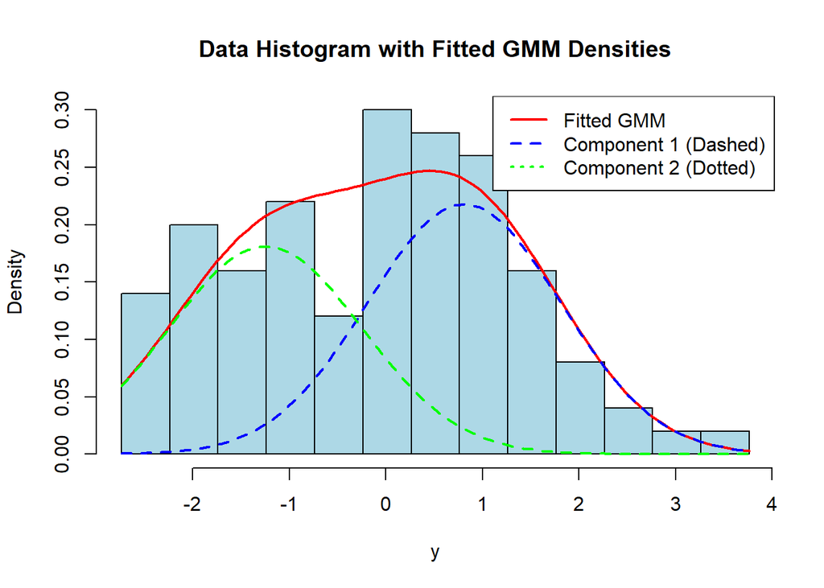

```r
# Visualize the fitted densities over histogram
hist(y, prob = TRUE, breaks = breaks_seq, col = "lightblue", main = "Data Histogram with Fitted GMM Densities", xlab = "y")
curve(w1 * dnorm(x, mean = mu1, sd = sigma1) + w2 * dnorm(x, mean = mu2, sd = sigma2), add = TRUE, col = "red", lwd = 2)
curve(w1 * dnorm(x, mean = mu1, sd = sigma1), add = TRUE, col = "blue", lty = 2, lwd = 2)
curve(w2 * dnorm(x, mean = mu2, sd = sigma2), add = TRUE, col = "green", lty = 2, lwd = 2)
legend("topright", legend = c("Fitted GMM", "Component 1 (Dashed)", "Component 2 (Dotted)"), col = c("red", "blue", "green"), lty = c(1, 2, 3), lwd = 2)
```

# 2f

## E-step

Apply Fubini’s theorem, and noting that $\{(y_i, u_i)\}_{i=1}^n$ are independent and identically distributed,
$$\begin{align}
\quad & \mathbb{E}_{\mathbf{y} \mid \tilde{\mathbf{\theta}}}Q(\theta
\mid \mathbf{y}, \tilde{\mathbf{\theta}}) \\
&= \mathbb{E}_{\mathbf{y} \mid \tilde{\mathbf{\theta}}}
\mathbb{E}_{\mathbf{u} \mid \mathbf{y}, \tilde{\mathbf{\theta}}}\log
[L^C(\mathbf{\theta} \mid \mathbf{y}, \mathbf{u})] \\
&= \mathbb{E}_{\mathbf{y}, \mathbf{u} \mid
\tilde{\mathbf{\theta}}}\log [L^C(\mathbf{\theta} \mid \mathbf{y},
\mathbf{u})] \\
&= -\frac{n}{2}\log(2\pi) + n \mathbb{E}_{y_i, u_i \mid
\tilde{\mathbf{\theta}}} \log [ \sigma_{u_i}^{-1}
\exp({-\frac{(y_i-\mu_{u_i})^2}{2\sigma_{u_i}^2}}) \cdot w_{u_i}] \\
\end{align}$$
Noting that $k=2$ and $\sigma_1^2=\sigma_2^2=1$. We have,
$$\begin{align}
\quad & \mathbb{E}_{y_i, u_i \mid \tilde{\mathbf{\theta}}} \log [
\sigma_{u_i}^{-1} \exp({-\frac{(y_i-\mu_{u_i})^2}{2\sigma_{u_i}^2}})
\cdot w_{u_i}] \\
&= \mathbb{E}_{y_i, u_i \mid \tilde{\mathbf{\theta}}} [\log w_{u_i}
-\frac{(y_i-\mu_{u_i})^2}{2})] \\
&= \mathbb{E}_{u_i \mid \tilde{\mathbf{\theta}}} [\log w_{u_i}] -
\frac{1}{2}\mathbb{E}_{y_i, u_i \mid \tilde{\mathbf{\theta}}}
[(y_i-\mu_{u_i})^2]
\end{align}$$
The first term is:
$$\begin{align}
\quad &\mathbb{E}_{u_i \mid \tilde{\mathbf{\theta}}} [\log w_{u_i}]
\\
&= \tilde{w}_1 \log{w_1} + \tilde{w}_2 \log{w_2} \\
&= \tilde{w}_1 \log{w_1} + (1-\tilde{w}_1) \log{(1-w_1)}
\end{align}$$
Noting that $y_i \mid u_i \sim \mathcal{N}(\mu_{u_i}, \sigma_{u_i}^2)$, and applying Fubini’s theorem and lemma 1, the second term is:
$$\begin{align}
\quad & \frac{1}{2}\mathbb{E}_{y_i, u_i \mid
\tilde{\mathbf{\theta}}} [(y_i-\mu_{u_i})^2] \\
&= \frac{1}{2}\mathbb{E}_{u_i \mid
\tilde{\mathbf{\theta}}}\mathbb{E}_{y_i \mid u_i
\tilde{\mathbf{\theta}}} [(y_i-\mu_{u_i})^2] \\
&= \frac{1}{2}\mathbb{E}_{u_i \mid \tilde{\mathbf{\theta}}}
[(\mu_{u_i}-\tilde{\mu}_{u_i})^2 + \tilde{\sigma}_{u_i}^2] \\
&= \frac{1}{2}\mathbb{E}_{u_i \mid \tilde{\mathbf{\theta}}}
[(\mu_{u_i}-\tilde{\mu}_{u_i})^2 + 1] \\
&= \frac{1}{2} [\tilde{w}_1(\mu_{1}-\tilde{\mu}_{1})^2
+\tilde{w}_2(\mu_{2}-\tilde{\mu}_{2})^2 +1] \\
&= \frac{1}{2}\tilde{w}_1(\mu_{1}-\tilde{\mu}_{1})^2
+\frac{1}{2}\tilde{w}_2(\mu_{2}-\tilde{\mu}_{2})^2 + \frac{1}{2}
\end{align}$$
Combining together:
$$\begin{align}
\quad & \mathbb{E}_{\mathbf{y} \mid \tilde{\mathbf{\theta}}}Q(\theta
\mid \mathbf{y}, \tilde{\mathbf{\theta}}) =
-\frac{n}{2}\log(2\pi) - \frac{n}{2} +
n\tilde{w}_1 \log{w_1} + n(1-\tilde{w}_1) \log{(1-w_1)} -
\frac{n}{2}\tilde{w}_1(\mu_{1}-\tilde{\mu}_{1})^2 -
\frac{n}{2}\tilde{w}_2(\mu_{2}-\tilde{\mu}_{2})^2
\end{align}$$
Note that this does not depend on our dataset anymore.

## M-step

For $w$, setting partial derivatives to zero yields:
$$\begin{align}
\frac{n\tilde{w}_1}{w_1} - \frac{n(1-\tilde{w}_1)}{1-w_1} &= 0 \\
w_1 &= \tilde{w}_1
\end{align}$$
For $\mu_1, \mu_2$:
$$\begin{align}
n(\mu_{1}-\tilde{\mu}_{1}) = 0 \quad &\text{and} \quad
n(\mu_{1}-\tilde{\mu}_{1}) = 0 \\
\mu_{1} = \tilde{\mu}_{1} \quad &\text{and} \quad \mu_{2} =
\tilde{\mu}_{2}
\end{align}$$
It can be seen that the population EM algorithm recovers exactly the initial estimates. In other words, it does not update. This result is also evident from its construction that the population EM algorithm does not utilize the empirical dataset at any point. If the initial estimate is the true parameter, then the population EM algorithm returns this true estimate without perturbation. This is an example of the self-consistency property of the population EM algorithm, from a theoretical point of view (Balakrishnan, Wainwright & Yu, 2017; McLachlan & Krishnan, 2008).

Compared the population EM algorithm in (f), the sample-based EM algorithm in question (e) is able to utilize samples to update the parameter values against the initial estimate, thus applicable to a large class of model fitting problems. The population EM algorithm is used for theoretical purpose in algorithm analysis and development, while the sample-based EM algorithm is used in application of model fitting.

# References

Balakrishnan, S., Wainwright, M., & Yu, B. (2017). Statistical guarantees for the EM algorithm: From population to sample-based analysis. The Annals of Statistics, 45(1), 77-120. http://dx.doi.org/10.1214/16-aos1435

McLachlan, G. J., & Krishnan, T. (2008). The EM algorithm and extensions (2nd ed.). Wiley-Interscience.